# cind820-eda

## CIND820 Big Data Analytics Project - EDA Data Mining for Customer Behavior Analysis in Retail Sales

```python
# import libraries

import pandas as pd
import numpy as np
import matplotlib.pyplot as plt
import matplotlib.dates as mdates
```

```python
# import dataset

path = r"C:\Users\jrroz\Desktop\June\TMU\Course Materials\CIND820\Data\Online Retail.xlsx"

df = pd.read_excel(path)
```

### 1. Data Summary and Structure

#### 1.1 High-Level Inspection

- High-level view of dataset: view head and tail
- Check count of unique values
- Check data types
- Check start and end dates

```python
df.info()
```

```
<class 'pandas.core.frame.DataFrame'>
RangeIndex: 541909 entries, 0 to 541908
Data columns (total 8 columns):
 #   Column       Non-Null Count   Dtype
---  ------       --------------   -----
 0   InvoiceNo    541909 non-null  object
 1   StockCode    541909 non-null  object
 2   Description  540455 non-null  object
 3   Quantity     541909 non-null  int64
 4   InvoiceDate  541909 non-null  datetime64[ns]
 5   UnitPrice    541909 non-null  float64
 6   CustomerID   406829 non-null  float64
 7   Country      541909 non-null  object
dtypes: datetime64[ns](1), float64(2), int64(1), object(4)
memory usage: 33.1+ MB
```

```python
df.head()
```

|  | InvoiceNo | StockCode | Description | Quantity | InvoiceDate | UnitPrice | CustomerID | Country |
| --- | --- | --- | --- | --- | --- | --- | --- | --- |
| 0 | 536365 | 85123A | WHITE HANGING HEART T-LIGHT HOLDER | 6 | 2010-12-01 08:26:00 | 2.55 | 17850.0 | United Kingdom |
| 1 | 536365 | 71053 | WHITE METAL LANTERN | 6 | 2010-12-01 08:26:00 | 3.39 | 17850.0 | United Kingdom |
| 2 | 536365 | 84406B | CREAM CUPID HEARTS COAT HANGER | 8 | 2010-12-01 08:26:00 | 2.75 | 17850.0 | United Kingdom |
| 3 | 536365 | 84029G | KNITTED UNION FLAG HOT WATER BOTTLE | 6 | 2010-12-01 08:26:00 | 3.39 | 17850.0 | United Kingdom |
| 4 | 536365 | 84029E | RED WOOLLY HOTTIE WHITE HEART. | 6 | 2010-12-01 08:26:00 | 3.39 | 17850.0 | United Kingdom |

```python
# count of unique values

num_rows = df.shape[0]
num_cols = df.shape[1]
num_customers = df['CustomerID'].nunique()
num_products = df['StockCode'].nunique()
num_invoices = df['InvoiceNo'].nunique()
num_countries = df['Country'].nunique()

print(num_rows, num_cols, num_customers, num_products, num_invoices, num_countries)
```

```
541909 8 4372 4070 25900 38
```

```python
# check data types

df.dtypes
```

```
InvoiceNo              object
StockCode              object
Description            object
Quantity                int64
InvoiceDate    datetime64[ns]
UnitPrice             float64
CustomerID            float64
Country                object
dtype: object
```

```python
# change CustomerID data type

df['CustomerID'] = df['CustomerID'].astype("object")

df.dtypes
```

```
InvoiceNo              object
StockCode              object
Description            object
Quantity                int64
InvoiceDate    datetime64[ns]
UnitPrice             float64
CustomerID             object
Country                object
dtype: object
```

```python
# check start and end dates

start_date = df['InvoiceDate'].min()
end_date = df['InvoiceDate'].max()

print(start_date)
print(end_date)
```

```
2010-12-01 08:26:00
2011-12-09 12:50:00
```

```python
# descriptive statistics for quantitative columns

df[['Quantity', 'UnitPrice']].describe()
```

|  | Quantity | UnitPrice |
| --- | --- | --- |
| count | 541909.000000 | 541909.000000 |
| mean | 9.552250 | 4.611114 |
| std | 218.081158 | 96.759853 |
| min | -80995.000000 | -11062.060000 |
| 25% | 1.000000 | 1.250000 |
| 50% | 3.000000 | 2.080000 |
| 75% | 10.000000 | 4.130000 |
| max | 80995.000000 | 38970.000000 |

#### 1.2 Quantitative Variables - Boxplots

- Check boxplots of key variables (Quantity, UnitPrice, Revenue)

##### 1.2.1 Quantity

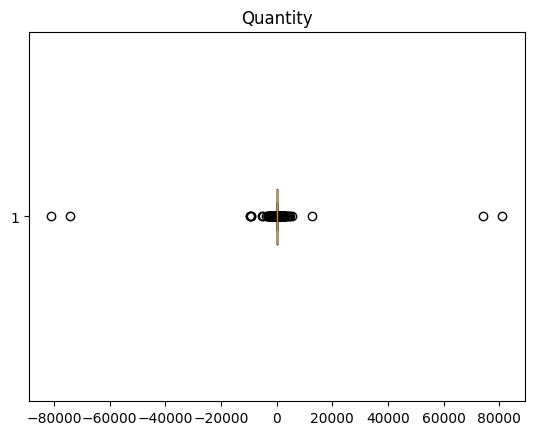

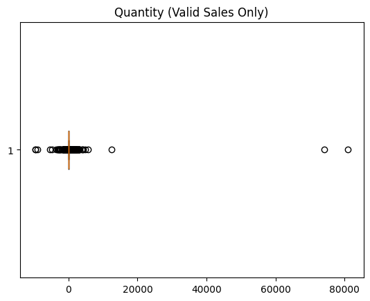

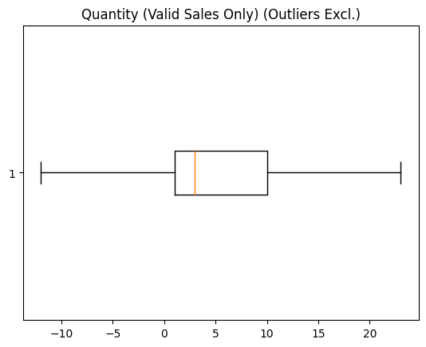

```python
# unfiltered

plt.boxplot(df['Quantity'], vert=False)
plt.title("Quantity")
plt.show()
# filtered - cancellations and bad debt excluded

filtered = df.loc[
    (~df["InvoiceNo"].str.startswith("C", na=False)) &
    (~df["InvoiceNo"].str.startswith("A", na=False)),
    "Quantity"
]

plt.boxplot(filtered.dropna(), vert=False)
plt.title("Quantity (Valid Sales Only)")
plt.show()
# filtered - cancellations and bad debt excluded
# outliers excluded

plt.boxplot(filtered.dropna(), vert=False, showfliers=False)
plt.title("Quantity (Valid Sales Only) (Outliers Excl.)")
plt.show()
```

- There are negative values for Quantity, likely representing cancellations or returns.
- In valid sales (excluding cancellations and bad debt adjustments), there are some extreme outliers — a few transactions have Quantity > 70,000.
- Even after removing cancellations, bad debt adjustments, and outliers, some negative Quantity values remain, likely due to returns.
- Around 50% of transactions have Quantity between 1 and 10, with a median of approximately 3–4.

##### 1.2.2 Unit Price

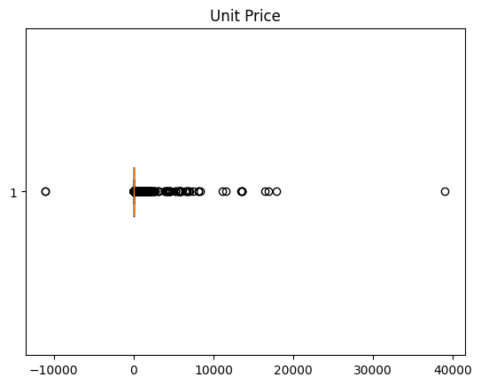

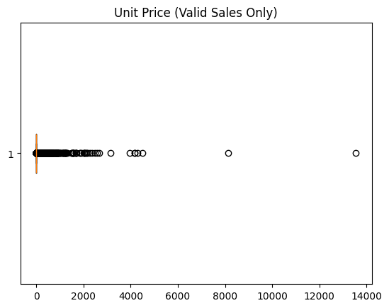

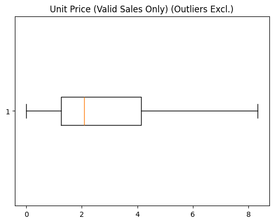

```python
# unfiltered

plt.boxplot(df['UnitPrice'].dropna(), vert=False)
plt.title('Unit Price')
plt.show()

# filtered - cancellations and bad debt excluded

filtered = df.loc[
    (df["UnitPrice"] > 0) &
    (~df["InvoiceNo"].str.startswith("C", na=False)) *
    (~df["InvoiceNo"].str.startswith("A", na=False)),
    "UnitPrice"
]

plt.boxplot(filtered.dropna(), vert=False)
plt.title("Unit Price (Valid Sales Only)")
plt.show()

# filtered - cancellations and bad debt excluded
# outliers excluded

plt.boxplot(filtered.dropna(), vert=False, showfliers=False)
plt.title("Unit Price (Valid Sales Only) (Outliers Excl.)")
plt.show()
```

##### 1.2.3 Revenue

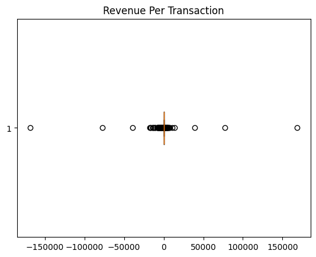

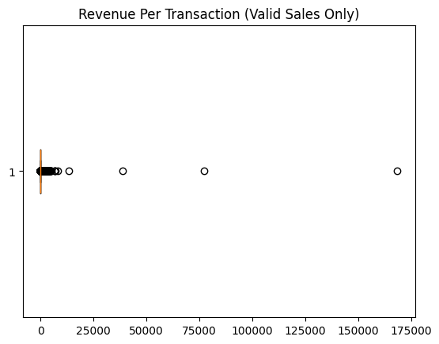

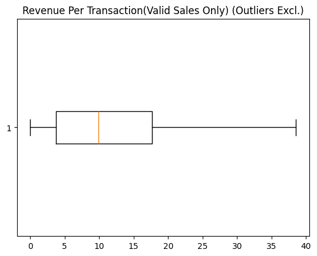

```python
# create revenue column

df['Revenue'] = df['Quantity'] * df['UnitPrice']

# unfiltered

plt.boxplot(df['Revenue'].dropna(), vert=False)
plt.title('Revenue Per Transaction')
plt.show()

# filtered - cancellations and bad debt excluded

filtered = df.loc[
    (df["Revenue"] > 0) &
    (~df["InvoiceNo"].str.startswith("C", na=False)) *
    (~df["InvoiceNo"].str.startswith("A", na=False)),
    "Revenue"
]

plt.boxplot(filtered.dropna(), vert=False)
plt.title("Revenue Per Transaction (Valid Sales Only)")
plt.show()

# filtered - cancellations and bad debt excluded
# outliers excluded

plt.boxplot(filtered.dropna(), vert=False, showfliers=False)
plt.title("Revenue Per Transaction(Valid Sales Only) (Outliers Excl.)")
plt.show()
```

- Boxplots of all revenue show large outliers, likely due to adjustments, returns, credits, or miscellaneous expenses.
- Valid sales still exhibit large outliers, primarily from high-priced or high-quantity transactions.
- After excluding outliers from valid sales, about 50% of transactions have revenue between £4 and £17, with a median of approximately £10.

```python
# total revenue

total_revenue = df['Revenue'].sum()

print(total_revenue)
```

```
9747747.933999998
```

#### 1.3 Qualitative Variables

##### 1.3.1 CustomerID (Transactions)

```python
# check count

df["CustomerID"].value_counts().reset_index()
```

|  | CustomerID | count |
| --- | --- | --- |
| 0 | 17841.0 | 7983 |
| 1 | 14911.0 | 5903 |
| 2 | 14096.0 | 5128 |
| 3 | 12748.0 | 4642 |
| 4 | 14606.0 | 2782 |
| ... | ... | ... |
| 4367 | 17986.0 | 1 |
| 4368 | 13256.0 | 1 |
| 4369 | 18184.0 | 1 |
| 4370 | 13747.0 | 1 |
| 4371 | 15195.0 | 1 |

4372 rows × 2 columns

```python
# average transactions per customer, std. dev

mean = df["CustomerID"].value_counts().mean()
stddev = df["CustomerID"].value_counts().std()

print("Average number of transactions per CustomerID:", mean, "\n" "Standard deviation: ", stddev)

# dataset is very skewed
```

```
Average number of transactions per CustomerID: 93.05329368709972
Standard deviation:  232.4716077416496
```

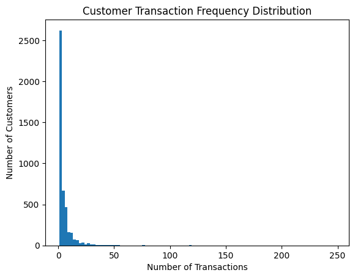

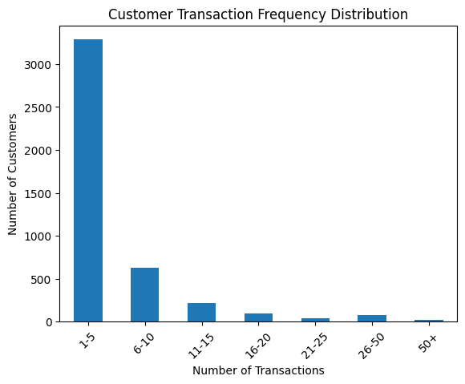

```python
# purchase frequency

purchase_frequency = df.groupby('CustomerID')['InvoiceNo'].nunique().sort_values(ascending=False)

plt.hist(purchase_frequency, bins=100)
plt.title("Customer Transaction Frequency Distribution")
plt.xlabel("Number of Transactions")
plt.ylabel("Number of Customers")
plt.show()

# with bins

bins = [0, 5, 10, 15, 20, 25, 50, 500]
labels = ['1-5', '6-10', '11-15', '16-20', '21-25', '26-50', '50+']

frequency_bins = pd.cut(purchase_frequency, bins=bins, labels=labels)

frequency_bins.value_counts().sort_index().plot(kind='bar')
plt.title("Customer Transaction Frequency Distribution")
plt.xlabel("Number of Transactions")
plt.ylabel("Number of Customers")
plt.xticks(rotation=45)
plt.show()
```

- The distribution is highly right-skewed.
- Vast majority of customers have 1 to 5 transactions, with the number of customers declining steeply beyond 6 transactions.

```python
frequency_bins.value_counts().sort_index()
```

```
InvoiceNo
1-5      3285
6-10      628
11-15     220
16-20      97
21-25      42
26-50      76
50+        24
Name: count, dtype: int64
```

```python
# revenue per customer

revenue_per_customer = df.groupby('CustomerID')['Revenue'].sum().sort_values(ascending=False)

# Top customers by revenue

revenue_per_customer.head(10)
```

```
CustomerID
14646.0    279489.02
18102.0    256438.49
17450.0    187482.17
14911.0    132572.62
12415.0    123725.45
14156.0    113384.14
17511.0     88125.38
16684.0     65892.08
13694.0     62653.10
15311.0     59419.34
Name: Revenue, dtype: float64
```

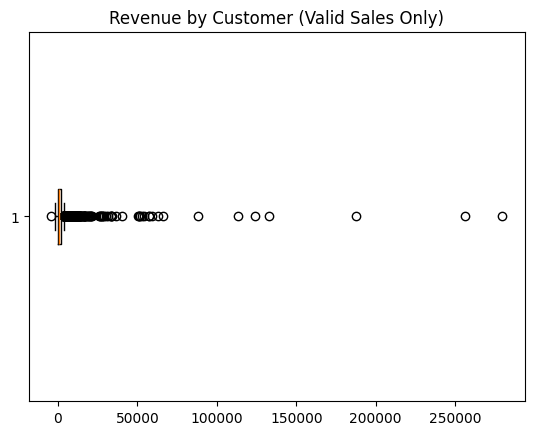

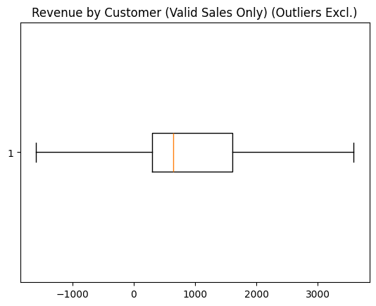

```python
# boxplot revenue per customer

plt.boxplot(revenue_per_customer.dropna(), vert=False)
plt.title("Revenue by Customer (Valid Sales Only)")
plt.show()

plt.boxplot(revenue_per_customer.dropna(), vert=False, showfliers=False)
plt.title("Revenue by Customer (Valid Sales Only) (Outliers Excl.)")
plt.show()
```

- Revenue by customer (valid sales only) shows large outliers, with some customers generating hundreds of thousands in revenue.
- A significant number of customers beyond the IQR generate thousands in revenue.
- After removing outliers, about 50% of customers generated between £250 and £1,700 in revenue, with a median of approximately £600.
- Some customers have large returns, shown by negative revenue values, which skews the data and lowers the average revenue per customer.

```python
# proportion of revenue accounted by top 10 customers

top_10_revenue_prop = (revenue_per_customer.head(10).sum()/total_revenue)*100

print(f"The top 10 customers by revenue account for {top_10_revenue_prop.round(1)}% of the total revenue.")
```

```
The top 10 customers by revenue account for 14.0% of the total revenue.
```

##### 1.3.2 Country

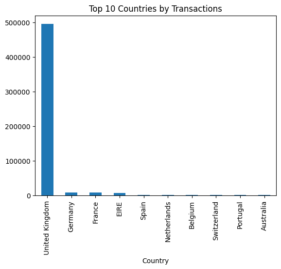

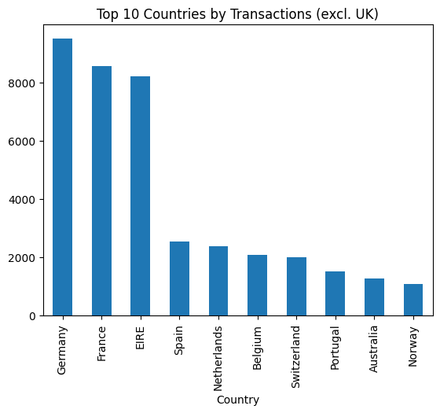

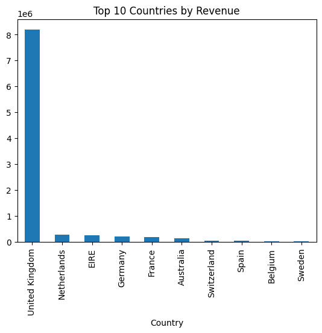

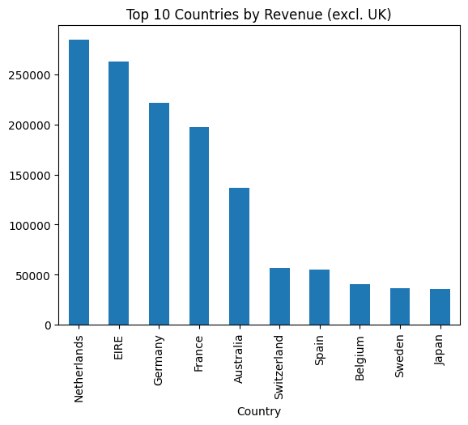

```python
# Top countries by transaction count

df['Country'].value_counts().head(10).plot(kind='bar')
plt.title("Top 10 Countries by Transactions")
plt.show()

# Top countries by transaction count (excl. UK)

df[df['Country'] != 'United Kingdom']['Country'].value_counts().head(10).plot(kind='bar')
plt.title("Top 10 Countries by Transactions (excl. UK)")
plt.show()

# Top countries by revenue

top_countries_revenue = df.groupby('Country')['Revenue'].sum().sort_values(ascending=False)

top_countries_revenue.head(10).plot(kind='bar')
plt.title("Top 10 Countries by Revenue")
plt.xlabel("Country")
plt.show()

# Top countries by revenue (excl. UK)

top_countries_revenue = top_countries_revenue[top_countries_revenue.index != 'United Kingdom']

top_countries_revenue.head(10).plot(kind='bar')
plt.title("Top 10 Countries by Revenue (excl. UK)")
plt.xlabel("Country")
plt.show()

# Normal Transactions vs Cancellations

# df['Cancellation'].value_counts().plot(kind='bar')
# plt.title("Normal Transactions vs Cancellations")
# plt.show()
```

- As a UK-based business, the United Kingdom accounts for the vast majority of total sales and transaction volume.
- Outside the UK, Germany, France, and Ireland rank as the top three markets by transaction frequency.
- Despite lower transaction counts than the top-3 countries mentioned above, the Netherlands generates higher total revenue, likely driven by bulk wholesale orders or higher-priced inventory.

##### 1.3.3 StockCode & Description

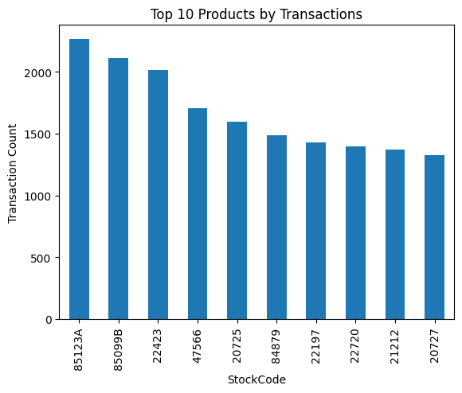

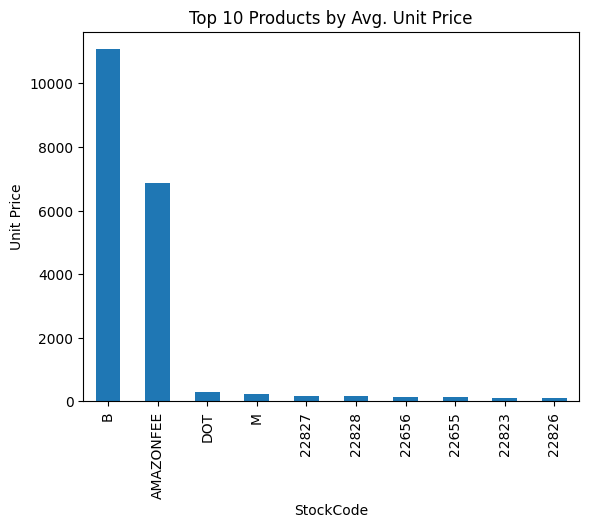

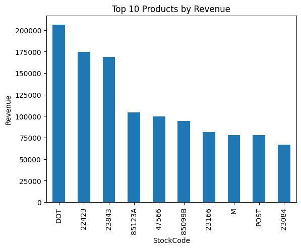

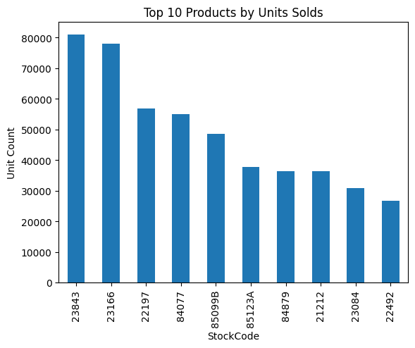

```python
# top merchandise by transactions, price, revenue, unit sales

valid_sales = df.loc[(df['UnitPrice'] > 0) & (df['Quantity'] > 0)]

# top merchandise by number of transactions

valid_sales['StockCode'].value_counts().head(10).plot(kind='bar')
plt.title("Top 10 Products by Transactions")
plt.ylabel("Transaction Count")
plt.show()

# top merchandise by average price

top_products_price = valid_sales.groupby('StockCode')['UnitPrice'].mean().sort_values(ascending=False)

top_products_price.head(10).plot(kind='bar')
plt.title("Top 10 Products by Avg. Unit Price")
plt.ylabel('Unit Price')
plt.show()

# top merchandise by revenue

top_products_revenue = valid_sales.groupby('StockCode')['Revenue'].sum().sort_values(ascending=False)

top_products_revenue.head(10).plot(kind='bar')
plt.title("Top 10 Products by Revenue")
plt.ylabel("Revenue")
plt.show()

# top merchandise by unit sales

top_products_units = valid_sales.groupby('StockCode')['Quantity'].sum().sort_values(ascending=False)

top_products_units.head(10).plot(kind='bar')
plt.title("Top 10 Products by Units Solds")
plt.ylabel("Unit Count")
plt.show()
```

- The dataset contains many miscellaneous transactions, such as Amazon fees, rebates, postage fees, etc., which should be considered and accounted for during analysis.

```python
# table of products that appear in above graphs

# transactions

top_products_transactions_list = valid_sales['StockCode'].value_counts().head(10).index.tolist()

# price

top_products_price_list = top_products_price.head(10).index.tolist()

# revenue

top_products_revenue_list = top_products_revenue.head(10).index.tolist()

# units

top_products_units_list = top_products_units.head(10).index.tolist()

# combined

top_products_combined_list = top_products_transactions_list + top_products_price_list + top_products_revenue_list + top_products_units_list

top_products_combined_descriptions = df.loc[df['StockCode'].isin(top_products_combined_list)]

top_products_combined_descriptions[['StockCode', 'Description']].value_counts()
```

```
StockCode  Description
85123A     WHITE HANGING HEART T-LIGHT HOLDER     2302
22423      REGENCY CAKESTAND 3 TIER               2200
85099B     JUMBO BAG RED RETROSPOT                2159
47566      PARTY BUNTING                          1727
20725      LUNCH BAG RED RETROSPOT                1638
84879      ASSORTED COLOUR BIRD ORNAMENT          1501
22720      SET OF 3 CAKE TINS PANTRY DESIGN       1473
21212      PACK OF 72 RETROSPOT CAKE CASES        1385
20727      LUNCH BAG  BLACK SKULL.                1350
POST       POSTAGE                                1252
23084      RABBIT NIGHT LIGHT                     1051
22197      POPCORN HOLDER                          865
DOT        DOTCOM POSTAGE                          709
22197      SMALL POPCORN HOLDER                    611
M          Manual                                  571
84077      WORLD WAR 2 GLIDERS ASSTD DESIGNS       542
22492      MINI PAINT SET VINTAGE                  390
23166      MEDIUM CERAMIC TOP STORAGE JAR          260
22655      VINTAGE RED KITCHEN CABINET              46
22826      LOVE SEAT ANTIQUE WHITE METAL            45
AMAZONFEE  AMAZON FEE                               34
22827      RUSTIC  SEVENTEEN DRAWER SIDEBOARD       29
22656      VINTAGE BLUE KITCHEN CABINET             26
22823      CHEST NATURAL WOOD 20 DRAWERS            13
85123A     CREAM HANGING HEART T-LIGHT HOLDER        9
22828      REGENCY MIRROR WITH SHUTTERS              7
B          Adjust bad debt                           3
23843      PAPER CRAFT , LITTLE BIRDIE               2
22423      damages                                   2
22823      test                                      2
22423      faulty                                    1
20725      LUNCH BAG RED SPOTTY                      1
22655      damages/showroom etc                      1
23084      Amazon                                    1
           website fixed                             1
           temp adjustment                           1
           for online retail orders                  1
           allocate stock for dotcom orders ta       1
           add stock to allocate online orders       1
84879      damaged                                   1
85123A     ?                                         1
           wrongly marked carton 22804               1
Name: count, dtype: int64
```

### 2. Data Quality Check

#### 2.1 Negative UnitPrice and Quantity

```python
# negative price check

negative_price = df[df["UnitPrice"] < 0]

negative_price
```

|  | InvoiceNo | StockCode | Description | Quantity | InvoiceDate | UnitPrice | CustomerID | Country | Revenue |
| --- | --- | --- | --- | --- | --- | --- | --- | --- | --- |
| 299983 | A563186 | B | Adjust bad debt | 1 | 2011-08-12 14:51:00 | -11062.06 | NaN | United Kingdom | -11062.06 |
| 299984 | A563187 | B | Adjust bad debt | 1 | 2011-08-12 14:52:00 | -11062.06 | NaN | United Kingdom | -11062.06 |

```python
# "Adjust bad debt" records

df.loc[df['InvoiceNo'].str.startswith("A", na = False), :]
```

|  | InvoiceNo | StockCode | Description | Quantity | InvoiceDate | UnitPrice | CustomerID | Country | Revenue |
| --- | --- | --- | --- | --- | --- | --- | --- | --- | --- |
| 299982 | A563185 | B | Adjust bad debt | 1 | 2011-08-12 14:50:00 | 11062.06 | NaN | United Kingdom | 11062.06 |
| 299983 | A563186 | B | Adjust bad debt | 1 | 2011-08-12 14:51:00 | -11062.06 | NaN | United Kingdom | -11062.06 |
| 299984 | A563187 | B | Adjust bad debt | 1 | 2011-08-12 14:52:00 | -11062.06 | NaN | United Kingdom | -11062.06 |

```python
# InvoiceNo starting with 'C' indicates cancellation

df.loc[df['InvoiceNo'].str.startswith("C", na = False), :]
```

|  | InvoiceNo | StockCode | Description | Quantity | InvoiceDate | UnitPrice | CustomerID | Country | Revenue |
| --- | --- | --- | --- | --- | --- | --- | --- | --- | --- |
| 141 | C536379 | D | Discount | -1 | 2010-12-01 09:41:00 | 27.50 | 14527.0 | United Kingdom | -27.50 |
| 154 | C536383 | 35004C | SET OF 3 COLOURED FLYING DUCKS | -1 | 2010-12-01 09:49:00 | 4.65 | 15311.0 | United Kingdom | -4.65 |
| 235 | C536391 | 22556 | PLASTERS IN TIN CIRCUS PARADE | -12 | 2010-12-01 10:24:00 | 1.65 | 17548.0 | United Kingdom | -19.80 |
| 236 | C536391 | 21984 | PACK OF 12 PINK PAISLEY TISSUES | -24 | 2010-12-01 10:24:00 | 0.29 | 17548.0 | United Kingdom | -6.96 |
| 237 | C536391 | 21983 | PACK OF 12 BLUE PAISLEY TISSUES | -24 | 2010-12-01 10:24:00 | 0.29 | 17548.0 | United Kingdom | -6.96 |
| ... | ... | ... | ... | ... | ... | ... | ... | ... | ... |
| 540449 | C581490 | 23144 | ZINC T-LIGHT HOLDER STARS SMALL | -11 | 2011-12-09 09:57:00 | 0.83 | 14397.0 | United Kingdom | -9.13 |
| 541541 | C581499 | M | Manual | -1 | 2011-12-09 10:28:00 | 224.69 | 15498.0 | United Kingdom | -224.69 |
| 541715 | C581568 | 21258 | VICTORIAN SEWING BOX LARGE | -5 | 2011-12-09 11:57:00 | 10.95 | 15311.0 | United Kingdom | -54.75 |
| 541716 | C581569 | 84978 | HANGING HEART JAR T-LIGHT HOLDER | -1 | 2011-12-09 11:58:00 | 1.25 | 17315.0 | United Kingdom | -1.25 |
| 541717 | C581569 | 20979 | 36 PENCILS TUBE RED RETROSPOT | -5 | 2011-12-09 11:58:00 | 1.25 | 17315.0 | United Kingdom | -6.25 |

9288 rows × 9 columns

```python
# check for other InvoiceNo starting with a letter

df.loc[df["InvoiceNo"].str.contains(r"^[A-Za-z]", na=False)]
```

|  | InvoiceNo | StockCode | Description | Quantity | InvoiceDate | UnitPrice | CustomerID | Country | Revenue |
| --- | --- | --- | --- | --- | --- | --- | --- | --- | --- |
| 141 | C536379 | D | Discount | -1 | 2010-12-01 09:41:00 | 27.50 | 14527.0 | United Kingdom | -27.50 |
| 154 | C536383 | 35004C | SET OF 3 COLOURED FLYING DUCKS | -1 | 2010-12-01 09:49:00 | 4.65 | 15311.0 | United Kingdom | -4.65 |
| 235 | C536391 | 22556 | PLASTERS IN TIN CIRCUS PARADE | -12 | 2010-12-01 10:24:00 | 1.65 | 17548.0 | United Kingdom | -19.80 |
| 236 | C536391 | 21984 | PACK OF 12 PINK PAISLEY TISSUES | -24 | 2010-12-01 10:24:00 | 0.29 | 17548.0 | United Kingdom | -6.96 |
| 237 | C536391 | 21983 | PACK OF 12 BLUE PAISLEY TISSUES | -24 | 2010-12-01 10:24:00 | 0.29 | 17548.0 | United Kingdom | -6.96 |
| ... | ... | ... | ... | ... | ... | ... | ... | ... | ... |
| 540449 | C581490 | 23144 | ZINC T-LIGHT HOLDER STARS SMALL | -11 | 2011-12-09 09:57:00 | 0.83 | 14397.0 | United Kingdom | -9.13 |
| 541541 | C581499 | M | Manual | -1 | 2011-12-09 10:28:00 | 224.69 | 15498.0 | United Kingdom | -224.69 |
| 541715 | C581568 | 21258 | VICTORIAN SEWING BOX LARGE | -5 | 2011-12-09 11:57:00 | 10.95 | 15311.0 | United Kingdom | -54.75 |
| 541716 | C581569 | 84978 | HANGING HEART JAR T-LIGHT HOLDER | -1 | 2011-12-09 11:58:00 | 1.25 | 17315.0 | United Kingdom | -1.25 |
| 541717 | C581569 | 20979 | 36 PENCILS TUBE RED RETROSPOT | -5 | 2011-12-09 11:58:00 | 1.25 | 17315.0 | United Kingdom | -6.25 |

9291 rows × 9 columns

```python
# flag bad debt fields and cancellations

df['BadDebt'] = df['InvoiceNo'].str.contains(r"^A", na=False)
df['Cancellation'] = df['InvoiceNo'].str.contains(r"^C", na=False)
```

```python
# negative quantity check

negative_quantity = df[df["Quantity"] < 0]

negative_quantity
```

|  | InvoiceNo | StockCode | Description | Quantity | InvoiceDate | UnitPrice | CustomerID | Country | Revenue | BadDebt | Cancellation |
| --- | --- | --- | --- | --- | --- | --- | --- | --- | --- | --- | --- |
| 141 | C536379 | D | Discount | -1 | 2010-12-01 09:41:00 | 27.50 | 14527.0 | United Kingdom | -27.50 | False | True |
| 154 | C536383 | 35004C | SET OF 3 COLOURED FLYING DUCKS | -1 | 2010-12-01 09:49:00 | 4.65 | 15311.0 | United Kingdom | -4.65 | False | True |
| 235 | C536391 | 22556 | PLASTERS IN TIN CIRCUS PARADE | -12 | 2010-12-01 10:24:00 | 1.65 | 17548.0 | United Kingdom | -19.80 | False | True |
| 236 | C536391 | 21984 | PACK OF 12 PINK PAISLEY TISSUES | -24 | 2010-12-01 10:24:00 | 0.29 | 17548.0 | United Kingdom | -6.96 | False | True |
| 237 | C536391 | 21983 | PACK OF 12 BLUE PAISLEY TISSUES | -24 | 2010-12-01 10:24:00 | 0.29 | 17548.0 | United Kingdom | -6.96 | False | True |
| ... | ... | ... | ... | ... | ... | ... | ... | ... | ... | ... | ... |
| 540449 | C581490 | 23144 | ZINC T-LIGHT HOLDER STARS SMALL | -11 | 2011-12-09 09:57:00 | 0.83 | 14397.0 | United Kingdom | -9.13 | False | True |
| 541541 | C581499 | M | Manual | -1 | 2011-12-09 10:28:00 | 224.69 | 15498.0 | United Kingdom | -224.69 | False | True |
| 541715 | C581568 | 21258 | VICTORIAN SEWING BOX LARGE | -5 | 2011-12-09 11:57:00 | 10.95 | 15311.0 | United Kingdom | -54.75 | False | True |
| 541716 | C581569 | 84978 | HANGING HEART JAR T-LIGHT HOLDER | -1 | 2011-12-09 11:58:00 | 1.25 | 17315.0 | United Kingdom | -1.25 | False | True |
| 541717 | C581569 | 20979 | 36 PENCILS TUBE RED RETROSPOT | -5 | 2011-12-09 11:58:00 | 1.25 | 17315.0 | United Kingdom | -6.25 | False | True |

10624 rows × 11 columns

```python
# check negative quantity for transactions that are not cancellations

noncancel_negquantity = negative_quantity.loc[~negative_quantity['InvoiceNo'].str.contains(r"^C", na=False)]

# transactions with negative quantities that are not cancellations
# lots of damages and adjustments

noncancel_negquantity['Description'].value_counts().index.tolist()
```

```
['check',
 'damages',
 'damaged',
 '?',
 'sold as set on dotcom',
 'Damaged',
 'thrown away',
 'Unsaleable, destroyed.',
 '??',
 'damages?',
 'ebay',
 'wet damaged',
 'smashed',
 'CHECK',
 'missing',
 'wet pallet',
 'Dotcom sales',
 'reverse 21/5/10 adjustment',
 'mixed up',
 'incorrect stock entry.',
 'adjustment',
 'wet rusty',
 'counted',
 'printing smudges/thrown away',
 'crushed',
 'wet/rusty',
 'sold as 1',
 '?missing',
 'stock check',
 'damages wax',
 'dotcom',
 '???missing',
 'rusty throw away',
 'faulty',
 'Dotcom',
 'Given away',
 'mouldy, thrown away.',
 'label mix up',
 'showroom',
 'MIA',
```

[output cut: 83 more lines]

```
 '???lost',
 'missing?',
 'wrongly marked carton 22804',
 'water damaged',
 '?? missing',
 '????missing',
 'rusty thrown away',
 'lost in space',
 'wet?',
 '???',
 'lost??',
 'wet',
 'wet boxes',
 '????damages????',
 'lost']
```

```python
a = df.loc[df['InvoiceNo'].str.startswith("A", na = False), :] # bad debt
b = df.loc[df['InvoiceNo'].str.startswith("C", na = False), :] # cancellations

# Summary

print(f"There are {a.shape[0]} fields with bad debt adjustments.")
print(f"There are {b.shape[0]} fields with cancellations.")
print(f"There are {noncancel_negquantity.shape[0]} fields with negative quantities that are not cancellations")
```

```
There are 3 fields with bad debt adjustments.
There are 9288 fields with cancellations.
There are 1336 fields with negative quantities that are not cancellations
```

#### 2.2 Check for Unit Price = 0

```python
# check dataset where UnitPrice == 0

df.loc[df['UnitPrice'] == 0]

# UnitPrice == 0 corresponds with large number of missing CustomerID and Description
```

|  | InvoiceNo | StockCode | Description | Quantity | InvoiceDate | UnitPrice | CustomerID | Country | Revenue | BadDebt | Cancellation |
| --- | --- | --- | --- | --- | --- | --- | --- | --- | --- | --- | --- |
| 622 | 536414 | 22139 | NaN | 56 | 2010-12-01 11:52:00 | 0.0 | NaN | United Kingdom | 0.0 | False | False |
| 1970 | 536545 | 21134 | NaN | 1 | 2010-12-01 14:32:00 | 0.0 | NaN | United Kingdom | 0.0 | False | False |
| 1971 | 536546 | 22145 | NaN | 1 | 2010-12-01 14:33:00 | 0.0 | NaN | United Kingdom | 0.0 | False | False |
| 1972 | 536547 | 37509 | NaN | 1 | 2010-12-01 14:33:00 | 0.0 | NaN | United Kingdom | 0.0 | False | False |
| 1987 | 536549 | 85226A | NaN | 1 | 2010-12-01 14:34:00 | 0.0 | NaN | United Kingdom | 0.0 | False | False |
| ... | ... | ... | ... | ... | ... | ... | ... | ... | ... | ... | ... |
| 536981 | 581234 | 72817 | NaN | 27 | 2011-12-08 10:33:00 | 0.0 | NaN | United Kingdom | 0.0 | False | False |
| 538504 | 581406 | 46000M | POLYESTER FILLER PAD 45x45cm | 240 | 2011-12-08 13:58:00 | 0.0 | NaN | United Kingdom | 0.0 | False | False |
| 538505 | 581406 | 46000S | POLYESTER FILLER PAD 40x40cm | 300 | 2011-12-08 13:58:00 | 0.0 | NaN | United Kingdom | 0.0 | False | False |
| 538554 | 581408 | 85175 | NaN | 20 | 2011-12-08 14:06:00 | 0.0 | NaN | United Kingdom | 0.0 | False | False |
| 538919 | 581422 | 23169 | smashed | -235 | 2011-12-08 15:24:00 | 0.0 | NaN | United Kingdom | -0.0 | False | False |

2515 rows × 11 columns

```python
# flag missing CustomerID and Description

df["CustomerID_NA"] = df["CustomerID"].isna()

df["Description_NA"] = df["Description"].isna()

df[["CustomerID_NA", "Description_NA"]]
```

|  | CustomerID_NA | Description_NA |
| --- | --- | --- |
| 0 | False | False |
| 1 | False | False |
| 2 | False | False |
| 3 | False | False |
| 4 | False | False |
| ... | ... | ... |
| 541904 | False | False |
| 541905 | False | False |
| 541906 | False | False |
| 541907 | False | False |
| 541908 | False | False |

541909 rows × 2 columns

```python
print(df.loc[(df['UnitPrice'] == 0) & (df['CustomerID_NA'] == False)].shape[0])
print(df.loc[(df['UnitPrice'] == 0) & (df['Description_NA'] == False)].shape[0])

# Only 40 instances of UnitPrice == 0 occurs when CustomerID is not NA
# 1061 instances of UnitPrice == 0 occurs when Description is not NA
# Consider removing fields with UnitPrice == 0 during analysis?
```

```
40
1061
```

#### 2.3 Missing Values

```python
# check for missing values

df.isna().sum()

# large quantity of null values for 'Description' and 'CustomerID'
```

```
InvoiceNo              0
StockCode              0
Description         1454
Quantity               0
InvoiceDate            0
UnitPrice              0
CustomerID        135080
Country                0
Revenue                0
BadDebt                0
Cancellation           0
CustomerID_NA          0
Description_NA         0
dtype: int64
```

```python
# count of records with CustomerID and Description == NA

print(df.loc[(df['CustomerID_NA'] == True) & (df['Description_NA'] == True)].shape)

# count of records with only CustomerID == NA

print(df.loc[(df['CustomerID_NA'] == True) & (df['Description_NA'] == False)].shape)

# count of records with only Description == NA

print(df.loc[(df['CustomerID_NA'] == False) & (df['Description_NA'] == True)].shape)

# All Description that are NA correspond with missing CustomerID
```

```
(1454, 13)
(133626, 13)
(0, 13)
```

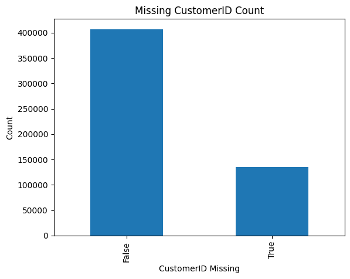

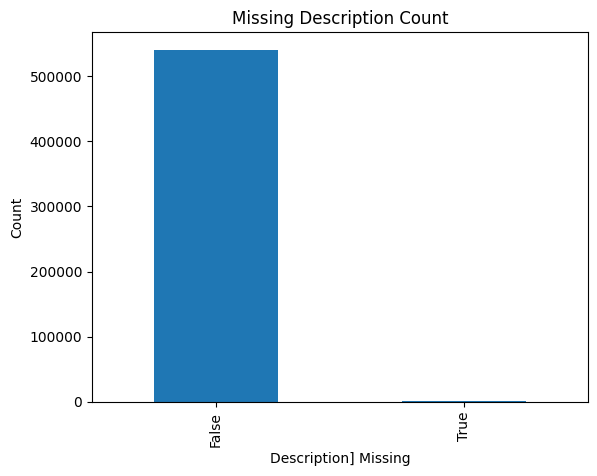

```python
# plot count of NA values

df['CustomerID_NA'].value_counts().plot(kind='bar')
plt.title("Missing CustomerID Count")
plt.xlabel("CustomerID Missing")
plt.ylabel("Count")
plt.show()

df['Description_NA'].value_counts().plot(kind='bar')
plt.title("Missing Description Count")
plt.xlabel("Description] Missing")
plt.ylabel("Count")
plt.show()
```

#### 2.4 Identify Real Sales

```python
# flag returns

df['IsReturn'] = df['Quantity'] < 0
```

```python
# check StockCodes that begin with a letter

df['IsStockCodeLetter'] = df['StockCode'].str.isalpha()

Alpha_StockCodes = df.loc[df['IsStockCodeLetter'] == True, ['StockCode', 'Description']]

Alpha_StockCodes.value_counts()
```

```
StockCode  Description
POST       POSTAGE                       1252
DOT        DOTCOM POSTAGE                 709
M          Manual                         571
D          Discount                        77
S          SAMPLES                         63
AMAZONFEE  AMAZON FEE                      34
CRUK       CRUK Commission                 16
DCGSSGIRL  GIRLS PARTY BAG                 13
DCGSSBOY   BOYS PARTY BAG                  11
PADS       PADS TO MATCH ALL CUSHIONS       4
B          Adjust bad debt                  3
m          Manual                           1
Name: count, dtype: int64
```

```python
# remove POST, DOT, M, D, S, AMAZONFEE, CRUK, B, m from StockCodes during analysis

not_real_product = ['POST', 'DOT', 'M', 'D', 'S', 'AMAZONFEE', 'CRUK', 'B', 'm']

df['RealProduct'] = ~df['StockCode'].isin(not_real_product)

df.loc[df['RealProduct'] == False].head()
```

|  | InvoiceNo | StockCode | Description | Quantity | InvoiceDate | UnitPrice | CustomerID | Country | Revenue | BadDebt | Cancellation | CustomerID_NA | Description_NA | IsReturn | IsStockCodeLetter | RealProduct |
| --- | --- | --- | --- | --- | --- | --- | --- | --- | --- | --- | --- | --- | --- | --- | --- | --- |
| 45 | 536370 | POST | POSTAGE | 3 | 2010-12-01 08:45:00 | 18.00 | 12583.0 | France | 54.00 | False | False | False | False | False | True | False |
| 141 | C536379 | D | Discount | -1 | 2010-12-01 09:41:00 | 27.50 | 14527.0 | United Kingdom | -27.50 | False | True | False | False | True | True | False |
| 386 | 536403 | POST | POSTAGE | 1 | 2010-12-01 11:27:00 | 15.00 | 12791.0 | Netherlands | 15.00 | False | False | False | False | False | True | False |
| 1123 | 536527 | POST | POSTAGE | 1 | 2010-12-01 13:04:00 | 18.00 | 12662.0 | Germany | 18.00 | False | False | False | False | False | True | False |
| 1814 | 536544 | DOT | DOTCOM POSTAGE | 1 | 2010-12-01 14:32:00 | 569.77 | NaN | United Kingdom | 569.77 | False | False | True | False | False | True | False |

```python
# check sum of discounts

total_discounts = df.loc[df['StockCode'] == 'D']['Revenue'].sum()

print(total_discounts)

# about $5700 in discounts - likely negligible during analysis
```

```
-5696.219999999999
```

### 3. Temporal Analysis

#### 3.1 Daily Aggregation

##### 3.1.1 Aggregate Data - Daily

```python
# check InvoiceDate

df['InvoiceDate'].dtype
```

```
dtype('<M8[ns]')
```

```python
# real sales (non negative quantity and price, no returns, real products)

real_sales = df.loc[(df['BadDebt'] == False) &
                    (df['Cancellation'] == False) &
                    (df['IsReturn'] == False) &
                    (df['RealProduct'] == True)].copy()
```

```python
# aggregate data by day

aggregate_day = df.groupby(df['InvoiceDate'].dt.date).agg({
    'InvoiceNo': 'count',  # number of transactions
    'Revenue': 'sum'       # total revenue
}).rename(columns={'InvoiceNo': 'Transactions'})

# real sales

aggregate_day_real_sales = real_sales.groupby(real_sales['InvoiceDate'].dt.date).agg({
    'InvoiceNo': 'count',  # number of transactions
    'Revenue': 'sum'       # total revenue
}).rename(columns={'InvoiceNo': 'Transactions'})
```

##### 3.1.2 Plot Data - Daily

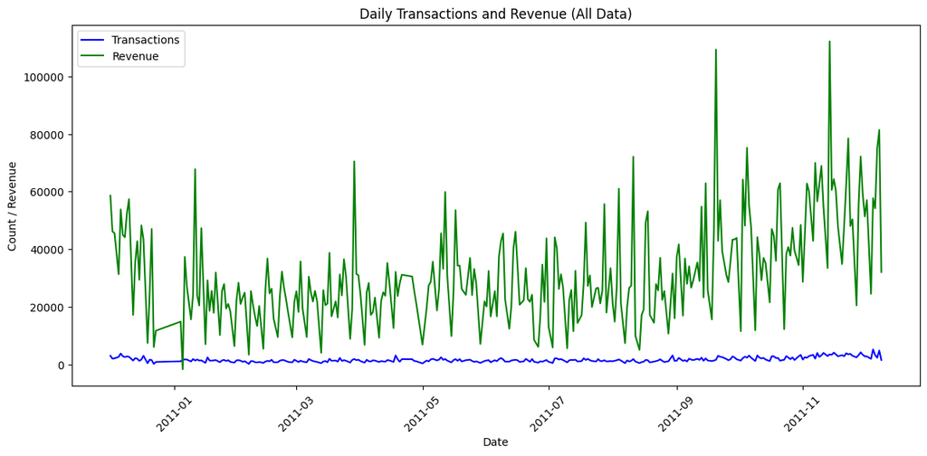

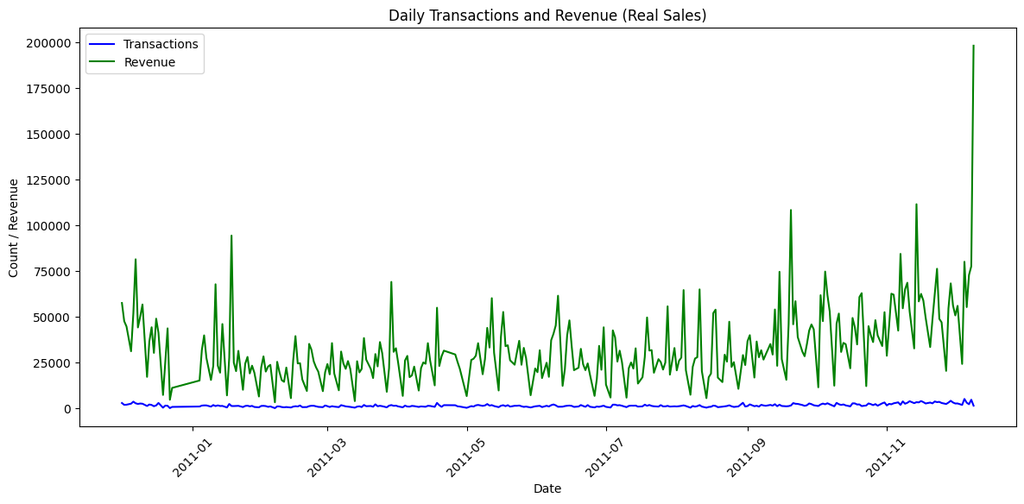

```python
# daily transaction volume (all data)

aggregate_day.plot(
    y=['Transactions','Revenue'],
    figsize=(14,6),
    title='Daily Transactions and Revenue (All Data)',
    color=['blue', 'green'])
plt.xlabel('Date')
plt.ylabel('Count / Revenue')
plt.legend()
plt.xticks(rotation=45)
plt.show()

# daily transaction volume (real sales)

aggregate_day_real_sales.plot(
    y=['Transactions','Revenue'],
    figsize=(14,6),
    title='Daily Transactions and Revenue (Real Sales)',
    color=['blue', 'green'])
plt.xlabel('Date')
plt.ylabel('Count / Revenue')
plt.legend()
plt.xticks(rotation=45)
plt.show()
```

#### 3.2 Weekly Aggregation

##### 3.2.1 Aggregate Data - Weekly

```python
# aggregate data by week

aggregate_week = df.resample('W', on='InvoiceDate').agg({
    'InvoiceNo' : 'count',
    'Revenue' : 'sum'
}).rename(columns={'InvoiceNo' : 'Transactions'})

# real data

aggregate_week_real_sales = real_sales.resample('W', on='InvoiceDate').agg({
    'InvoiceNo' : 'count',
    'Revenue' : 'sum'
}).rename(columns={'InvoiceNo' : 'Transactions'})
```

##### 3.2.2 Plot Data - Weekly

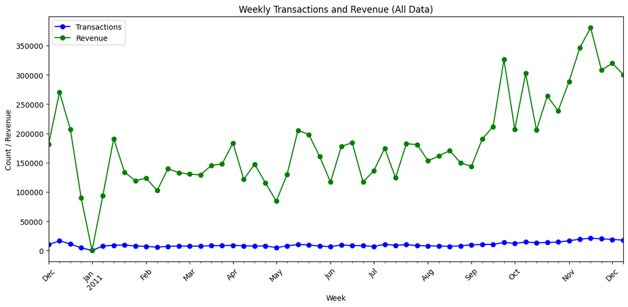

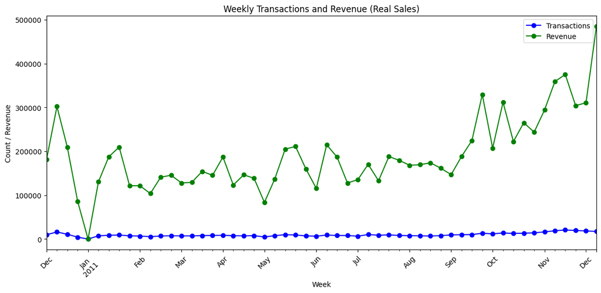

```python
# weekly transaction volume (all data)

aggregate_week.plot(
    y=['Transactions','Revenue'],
    figsize=(14,6),
    title='Weekly Transactions and Revenue (All Data)',
    color=['blue', 'green'],
    marker='o')
plt.xlabel('Week')
plt.ylabel('Count / Revenue')
plt.legend()
plt.xticks(rotation=45)
plt.show()

# weekly transaction volume (real sales)

aggregate_week_real_sales.plot(
    y=['Transactions','Revenue'],
    figsize=(14,6),
    title='Weekly Transactions and Revenue (Real Sales)',
    color=['blue', 'green'],
    marker='o')
plt.xlabel('Week')
plt.ylabel('Count / Revenue')
plt.legend()
plt.xticks(rotation=45)
plt.show()
```

#### 3.3 Monthly Aggregation

##### 3.3.1 Aggregate Data - Monthly

```python
# aggregate data by month

aggregate_month = df.resample('ME', on='InvoiceDate').agg({
    'InvoiceNo' : 'count',
    'Revenue' : 'sum'
}).rename(columns={'InvoiceNo' : 'Transactions'})

# real data

aggregate_month_real_sales = real_sales.resample('ME', on='InvoiceDate').agg({
    'InvoiceNo' : 'count',
    'Revenue' : 'sum'
}).rename(columns={'InvoiceNo' : 'Transactions'})
```

##### 3.3.2 Plot Data - Monthly

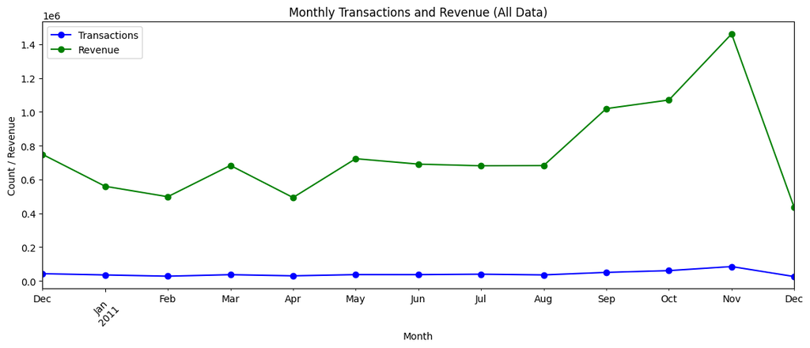

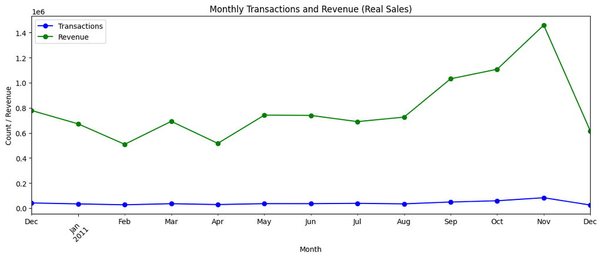

```python
# monthly transaction volume (all data)

aggregate_month.plot(
    y=['Transactions','Revenue'],
    figsize=(14,5),
    title='Monthly Transactions and Revenue (All Data)',
    color=['blue', 'green'],
    marker='o')
plt.xlabel('Month')
plt.ylabel('Count / Revenue')
plt.legend()
plt.xticks(rotation=45)
plt.show()

# monthly transaction volume (real sales)

aggregate_month_real_sales.plot(
    y=['Transactions','Revenue'],
    figsize=(14,5),
    title='Monthly Transactions and Revenue (Real Sales)',
    color=['blue', 'green'],
    marker='o')
plt.xlabel('Month')
plt.ylabel('Count / Revenue')
plt.legend()
plt.xticks(rotation=45)
plt.show()
```

- Monthly trends are smoother compared to daily and weekly trends, making overall patterns easier to observe.
- December 2011 shows lower revenue and transaction counts, likely due to the incomplete month of data.
- Sales tend to ramp up in the months leading up to the holiday season.
- Sales decline in the months following the holiday season, reflecting seasonal fluctuations.

#### 3.4 Day-of-Week Analysis

##### 3.4.1 Aggregate Data - Day of Week

```python
# create Day of Week column

df['DayOfWeek'] = df['InvoiceDate'].dt.day_name()
real_sales['DayOfWeek'] = real_sales['InvoiceDate'].dt.day_name()

# aggregate data

dayofweek = df.groupby('DayOfWeek').agg({
    'InvoiceNo' : 'count',
    'Revenue' : 'sum'
}).rename(columns={'InvoiceNo' : 'Transactions'})

# real sales

dayofweek_real_sales = real_sales.groupby('DayOfWeek').agg({
    'InvoiceNo' : 'count',
    'Revenue' : 'sum'
}).rename(columns={'InvoiceNo' : 'Transactions'})

# reorder days

days_order = ['Monday','Tuesday','Wednesday','Thursday','Friday','Saturday','Sunday']

dayofweek = dayofweek.reindex(days_order)
dayofweek_real_sales = dayofweek_real_sales.reindex(days_order)
```

##### 3.4.2 Plot Data - Day of Week

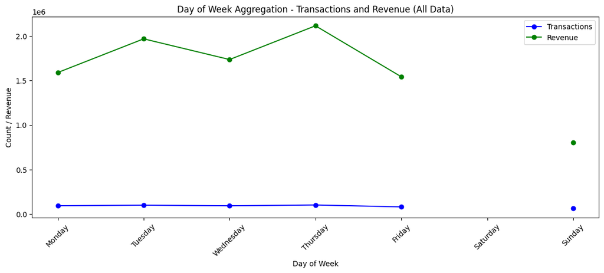

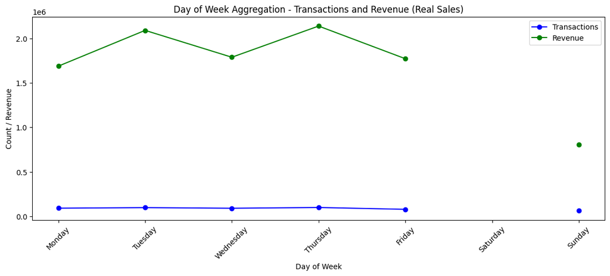

```python
# transaction volume and revenue by day of week (all)

dayofweek.plot(
    y=['Transactions','Revenue'],
    figsize=(14,5),
    title='Day of Week Aggregation - Transactions and Revenue (All Data)',
    color=['blue', 'green'],
    marker='o')
plt.xlabel('Day of Week')
plt.ylabel('Count / Revenue')
plt.legend()
plt.xticks(rotation=45)
plt.show()

# transaction volume and revenue by day of week (real sales)

dayofweek_real_sales.plot(
    y=['Transactions','Revenue'],
    figsize=(14,5),
    title='Day of Week Aggregation - Transactions and Revenue (Real Sales)',
    color=['blue', 'green'],
    marker='o')
plt.xlabel('Day of Week')
plt.ylabel('Count / Revenue')
plt.legend()
plt.xticks(rotation=45)
plt.show()
```

- The dataset contains zero recorded sales on Saturdays, strongly suggesting that the store is closed or does not process any transactions on that day.
- Revenue consistently peaks on Thursdays before experiencing a steep decline through Friday and into the weekend.
- While revenue fluctuates throughout the week, transaction volume remains relatively stable, reaching its lowest point on Sundays.
- There is a marginal discrepancy between "all data" and "real sales" at the weekly level, indicating that administrative fees and returns are distributed fairly evenly and do not significantly skew the weekly performance trends.